# NARW Occurrence GAM Model Testing

```r
summary(m_RWoccwk_bt)
```

```
#> Family:  c("BEINF", "Beta Inflated")
#>
#> Call:  gamlss(formula = percent_occurrence/100 ~ scs(Month) +
#>     Site + pb(bottom_temp, max.df = 7, inter = 10) +
#>     pb(stratification, max.df = 7, inter = 10) + pb(sss,
#>     max.df = 7) + as.factor(Year) + pb(phase, max.df = 7,
#>     inter = 5) + device_type + PercentOccurrence_l1 +
#>     cold_pool_index, nu.formula = ~pbc(Month, control = pbc.control(method = "GAIC")),
#>     family = BEINF, data = weekly_model_data, control = gamlss.control(c.crit = 0.01,
#>         n.cyc = 100, trace = FALSE))
#>
#> Fitting method: RS()
#>
#> ------------------------------------------------------------------
#> Mu link function:  logit
#> Mu Coefficients:
#>                                             Estimate Std. Error t value
#> (Intercept)                                10.953889   3.745343   2.925
#> scs(Month)                                 -0.021137   0.020458  -1.033
#> SiteA7M                                     0.331320   0.155716   2.128
#> SiteRTWB                                    0.323061   0.217316   1.487
#> SiteT2M                                     0.466352   0.202910   2.298
#> pb(bottom_temp, max.df = 7, inter = 10)    -0.008987   0.023154  -0.388
#> pb(stratification, max.df = 7, inter = 10) -3.983036   0.973870  -4.090
#> pb(sss, max.df = 7)                        -0.332920   0.116825  -2.850
#> as.factor(Year)2014                        -0.492247   0.245050  -2.009
#> as.factor(Year)2016                        -0.525798   0.168374  -3.123
#> as.factor(Year)2017                        -1.138157   0.191325  -5.949
#> as.factor(Year)2021                        -0.705020   0.399412  -1.765
#> as.factor(Year)2022                        -0.861245   0.299995  -2.871
#> as.factor(Year)2023                        -0.849517   0.243108  -3.494
#> as.factor(Year)2024                        -1.243676   0.301556  -4.124
#> pb(phase, max.df = 7, inter = 5)           -0.216342   0.227269  -0.952
#> PercentOccurrence_l1                        0.003271   0.001930   1.694
#> cold_pool_indexPresent                     -0.587312   0.454339  -1.293
#>                                            Pr(>|t|)
#> (Intercept)                                0.003555 **
#> scs(Month)                                 0.301855
#> SiteA7M                                    0.033694 *
#> SiteRTWB                                   0.137551
```

[output cut: 39 more lines]

```
#> Signif. codes:  0 '***' 0.001 '**' 0.01 '*' 0.05 '.' 0.1 ' ' 1
#>
#> ------------------------------------------------------------------
#> NOTE: Additive smoothing terms exist in the formulas:
#>  i) Std. Error for smoothers are for the linear effect only.
#> ii) Std. Error for the linear terms maybe are not accurate.
#> ------------------------------------------------------------------
#> No. of observations in the fit:  776
#> Degrees of Freedom for the fit:  42.43941
#>       Residual Deg. of Freedom:  733.5606
#>                       at cycle:  4
#>
#> Global Deviance:     507.7258
#>             AIC:     592.6047
#>             SBC:     790.1241
```

```r
#m_RWoccwk <- gamlss::stepGAIC(m_RWoccwk)
```

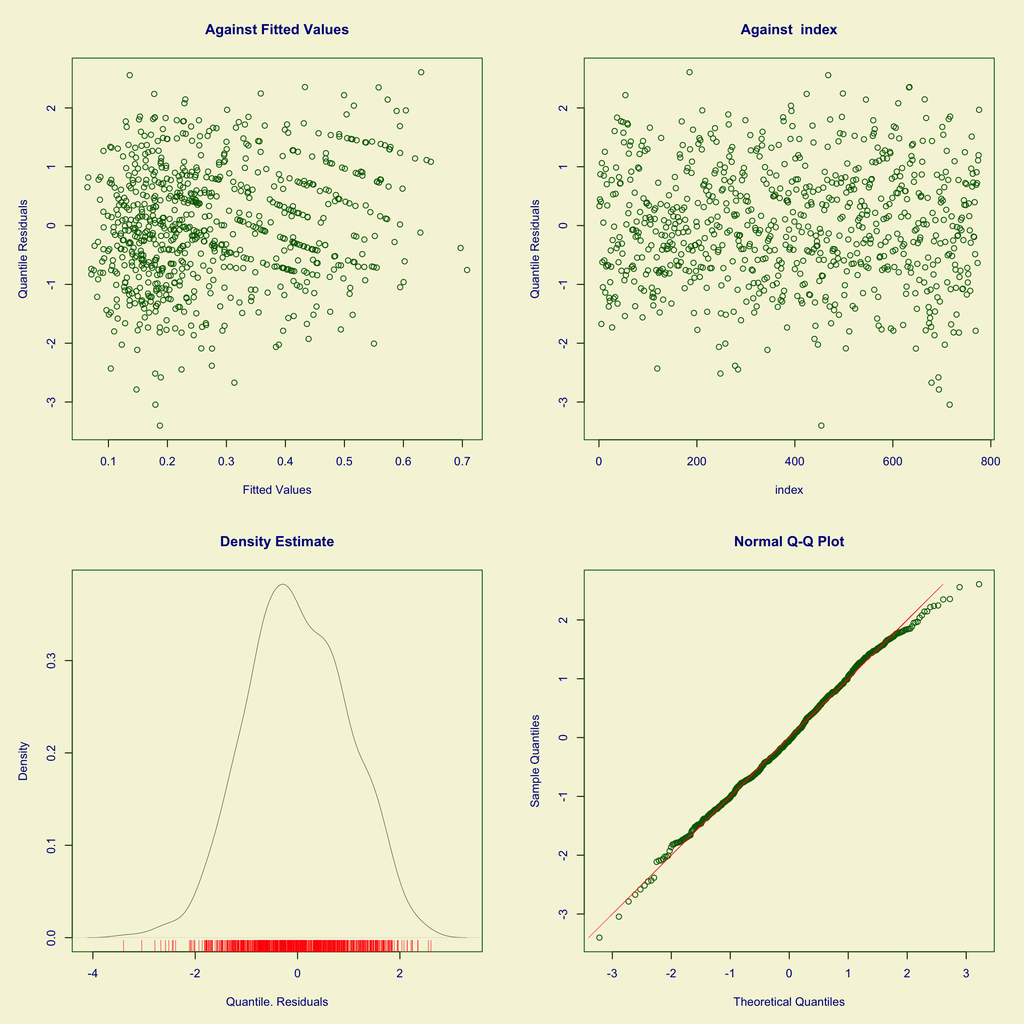

```
#>   Summary of the Randomised Quantile Residuals
#>                            mean   =  -0.004552471
#>                        variance   =  0.9774381
#>                coef. of skewness  =  -0.04316941
#>                coef. of kurtosis  =  2.758492
#> Filliben correlation coefficient  =  0.9983753
```

```r
## Model diagnostics ----
plot(m_RWoccwk_sst)
```

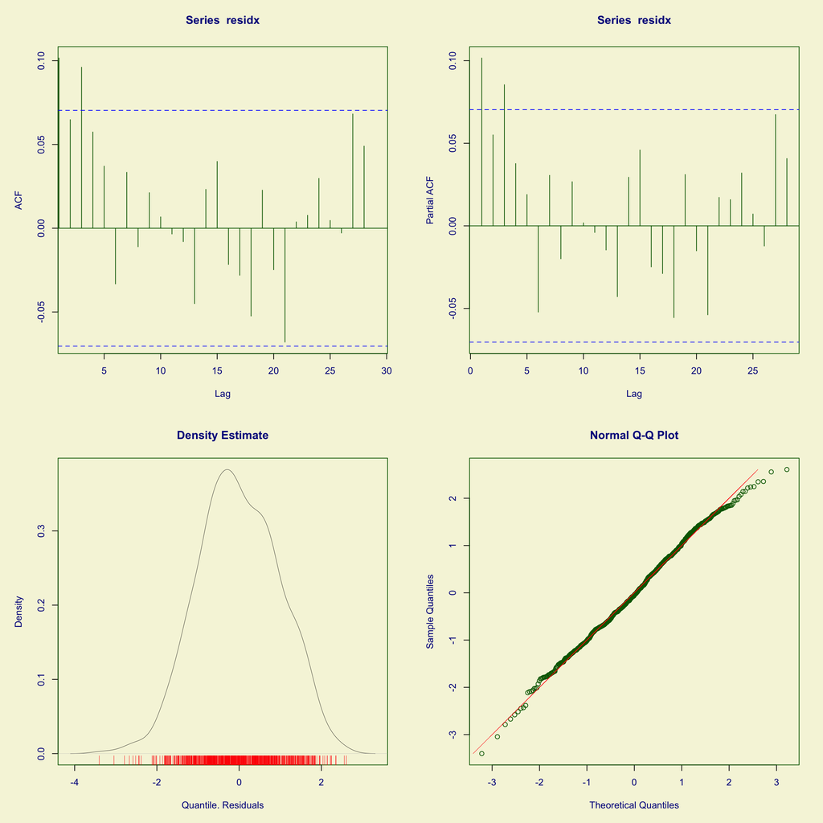

```
#>   Summary of the Randomised Quantile Residuals
#>                            mean   =  -0.004552471
#>                        variance   =  0.9774381
#>                coef. of skewness  =  -0.04316941
#>                coef. of kurtosis  =  2.758492
#> Filliben correlation coefficient  =  0.9983753
```

```r
plot(m_RWoccwk_sst, ts = TRUE)
```

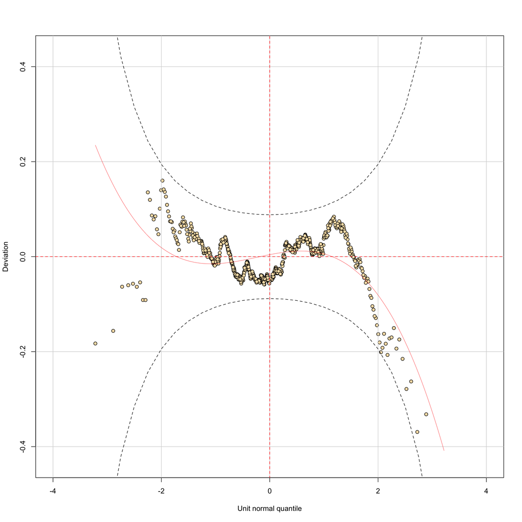

```r
wp(m_RWoccwk_sst)
```

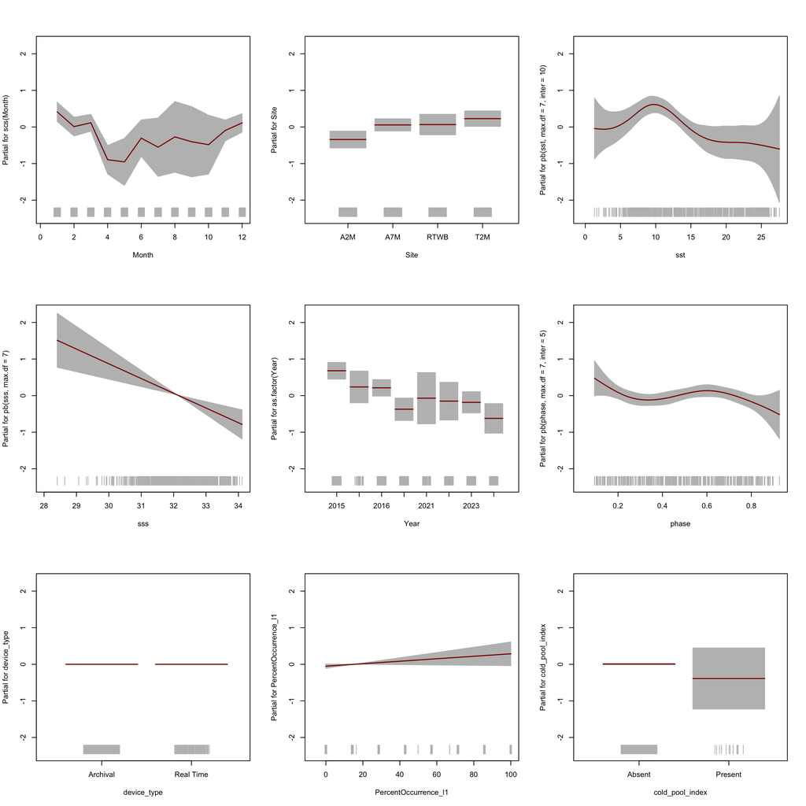

```r
par(mfrow = c(3, 3))
term.plot(m_RWoccwk_sst, rug = TRUE)
```

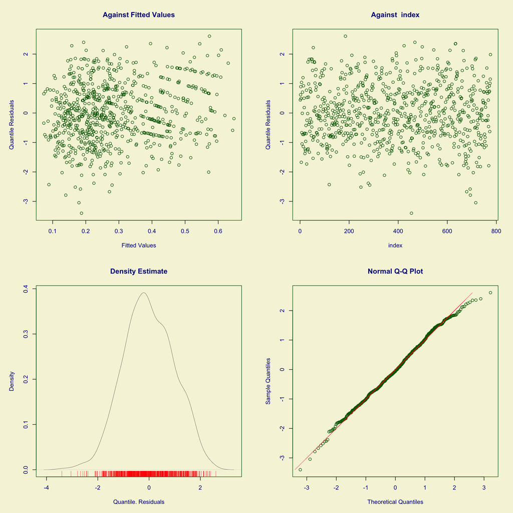

```
#>   Summary of the Randomised Quantile Residuals
#>                            mean   =  -0.00599773
#>                        variance   =  0.9758078
#>                coef. of skewness  =  -0.03641506
#>                coef. of kurtosis  =  2.770304
#> Filliben correlation coefficient  =  0.9983222
```

```r
plot(m_RWoccwk_strat)
```

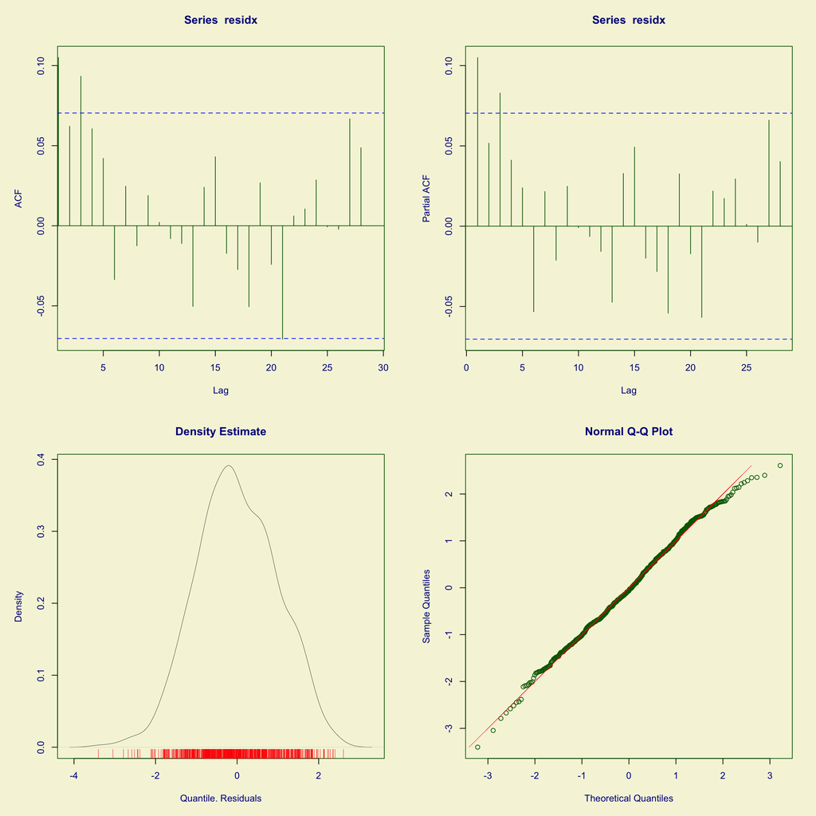

```
#>   Summary of the Randomised Quantile Residuals
#>                            mean   =  -0.00599773
#>                        variance   =  0.9758078
#>                coef. of skewness  =  -0.03641506
#>                coef. of kurtosis  =  2.770304
#> Filliben correlation coefficient  =  0.9983222
```

```r
plot(m_RWoccwk_strat, ts = TRUE)
```

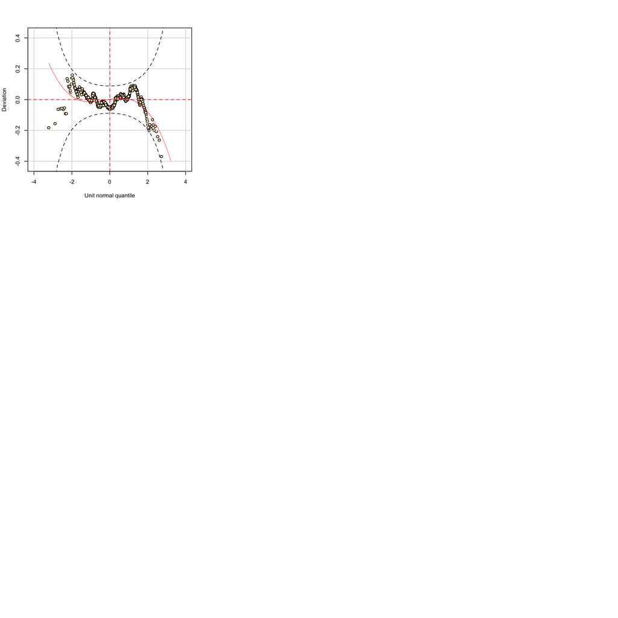

```r
wp(m_RWoccwk_strat)

par(mfrow = c(3, 3))
```

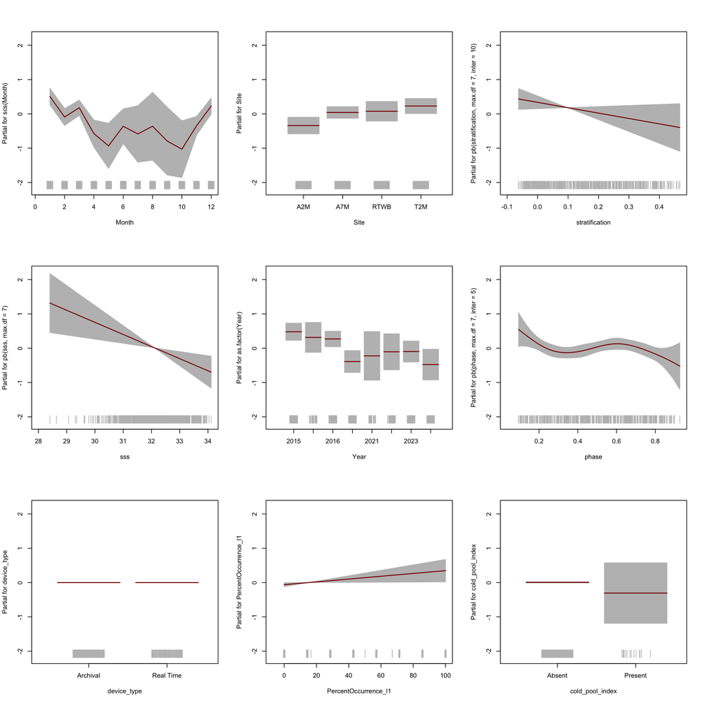

```r
term.plot(m_RWoccwk_strat, rug = TRUE)
```

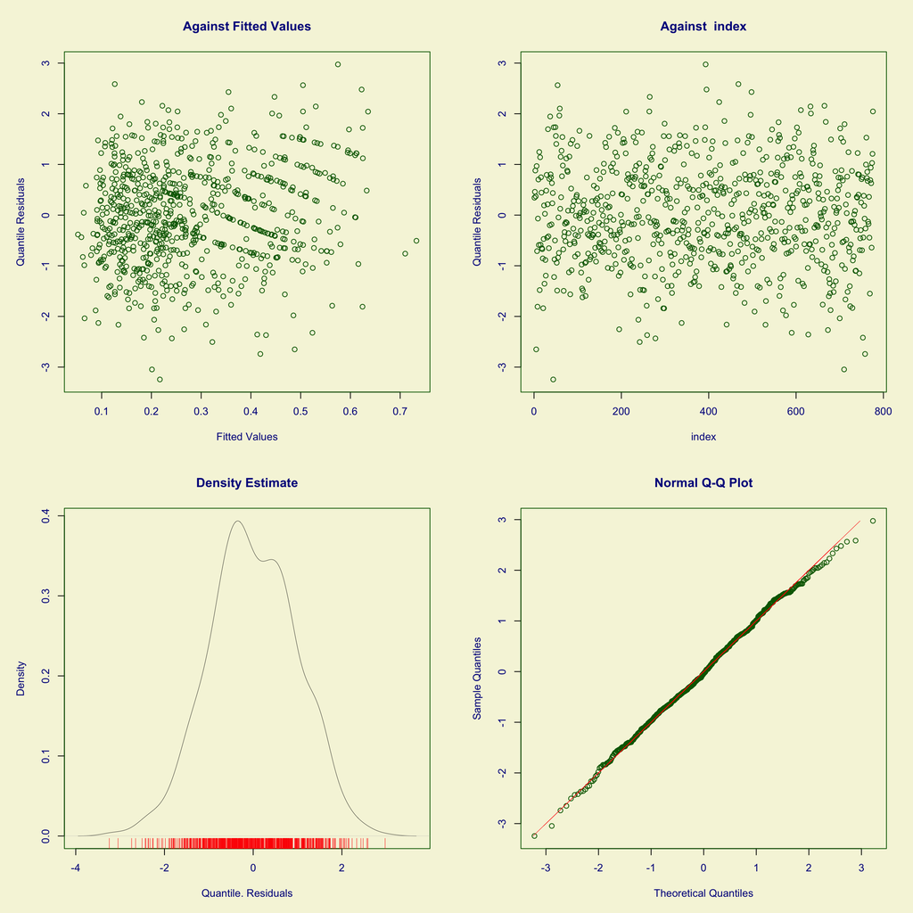

```
#>   Summary of the Randomised Quantile Residuals
#>                            mean   =  0.001536795
#>                        variance   =  0.978703
#>                coef. of skewness  =  -0.04594107
#>                coef. of kurtosis  =  2.861279
#> Filliben correlation coefficient  =  0.9991284
```

```r
plot(m_RWoccwk_bt)
```

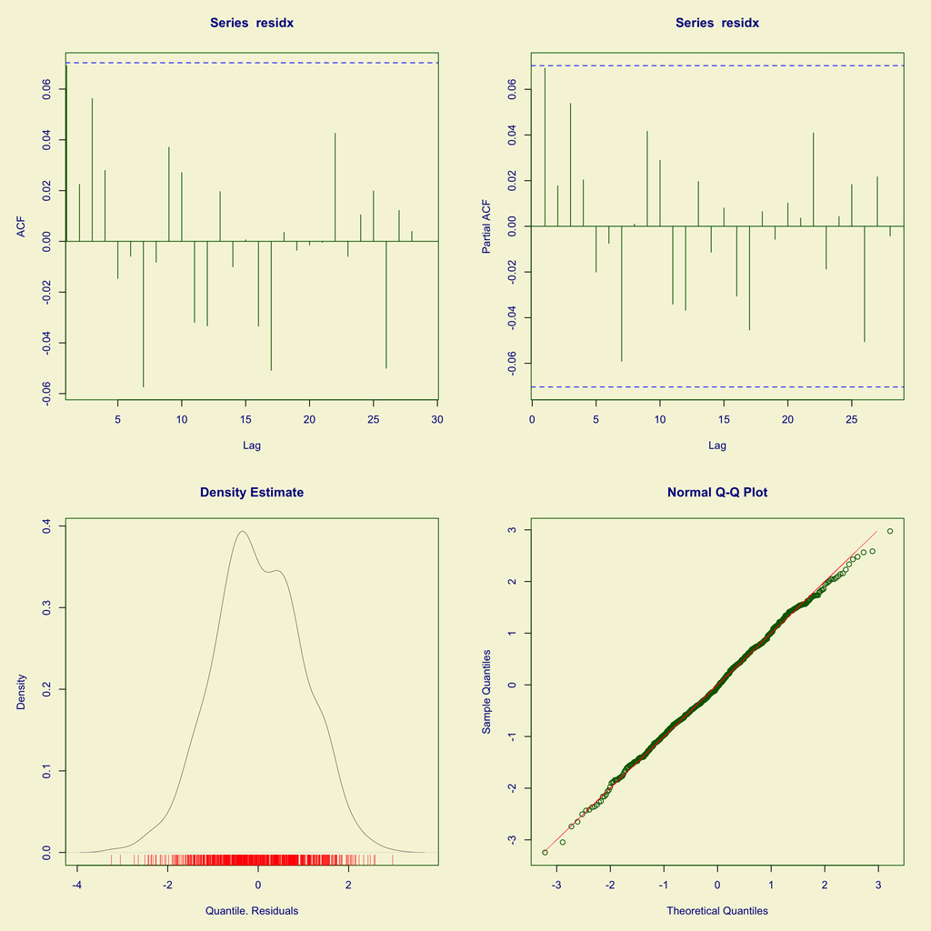

```
#>   Summary of the Randomised Quantile Residuals
#>                            mean   =  0.001536795
#>                        variance   =  0.978703
#>                coef. of skewness  =  -0.04594107
#>                coef. of kurtosis  =  2.861279
#> Filliben correlation coefficient  =  0.9991284
```

```r
plot(m_RWoccwk_bt, ts = TRUE)
```

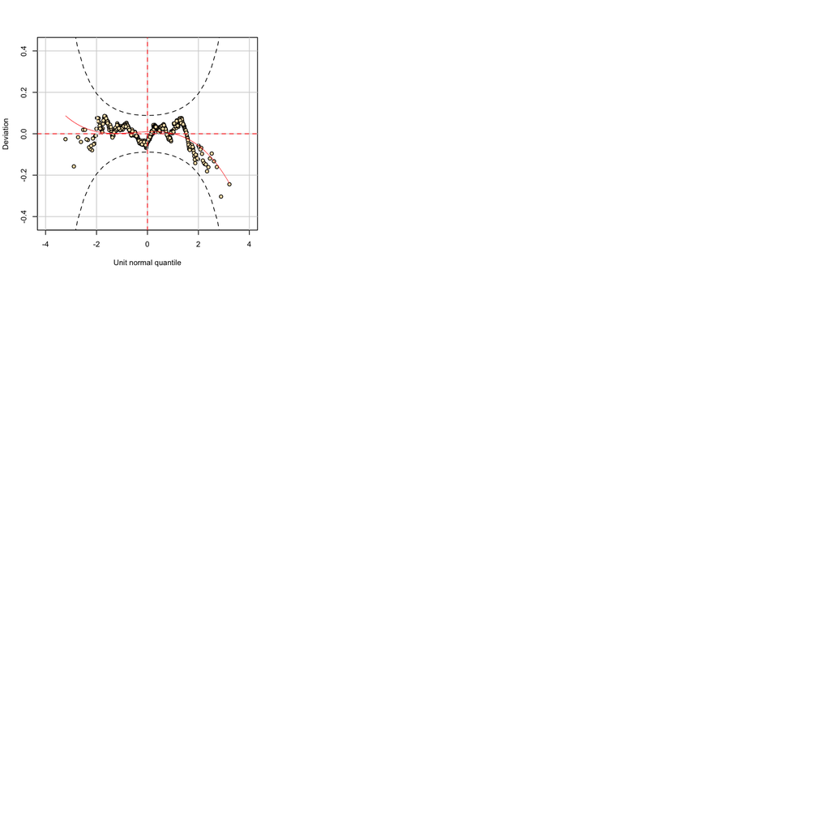

```r
wp(m_RWoccwk_bt)

par(mfrow = c(3, 3))
```

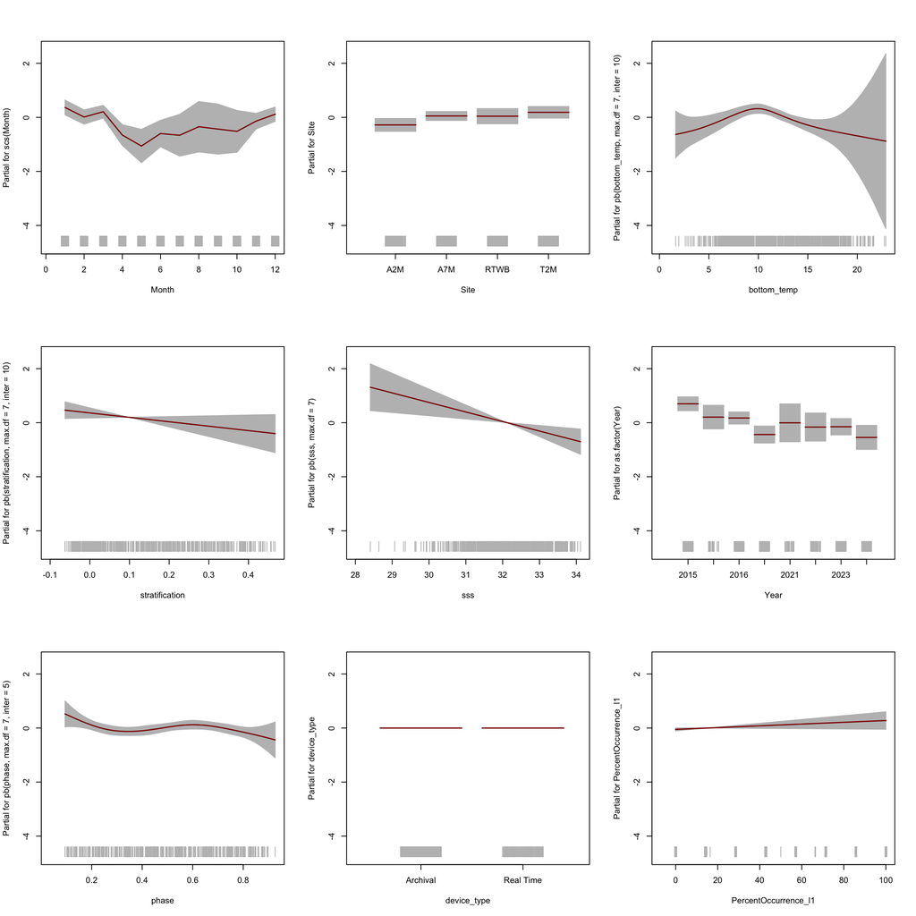

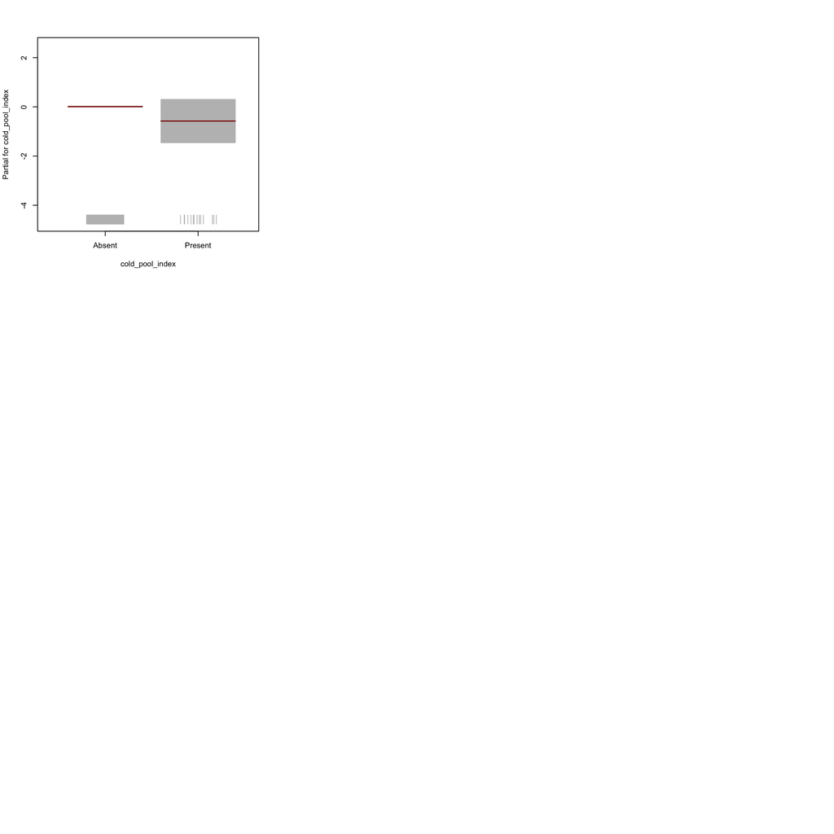

```r
term.plot(m_RWoccwk_bt, rug = TRUE)
```

Results for the weekly `nu` parameter (the probability of exact zero occurrence):

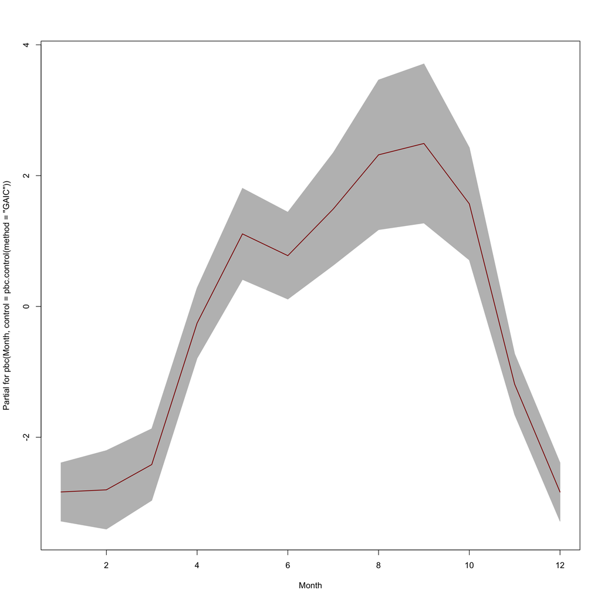

```r
term.plot(m_RWoccwk_sst, parameter = "nu")
```

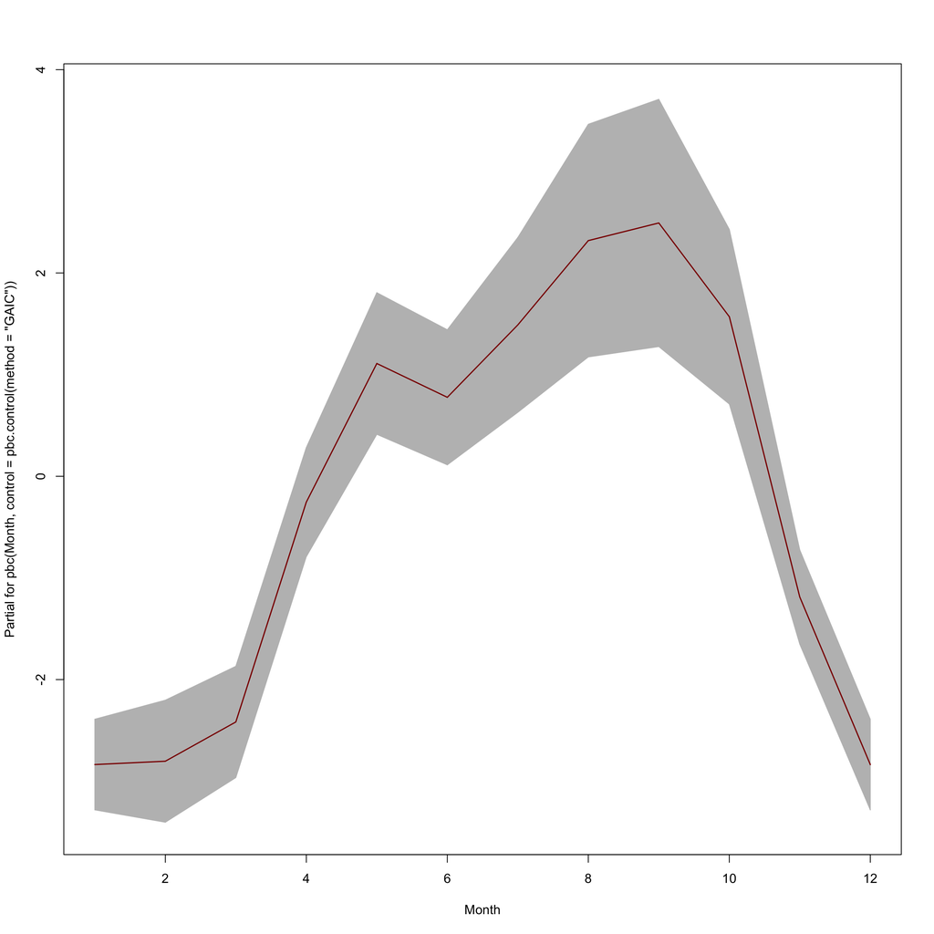

```r
term.plot(m_RWoccwk_strat, parameter = "nu")
```

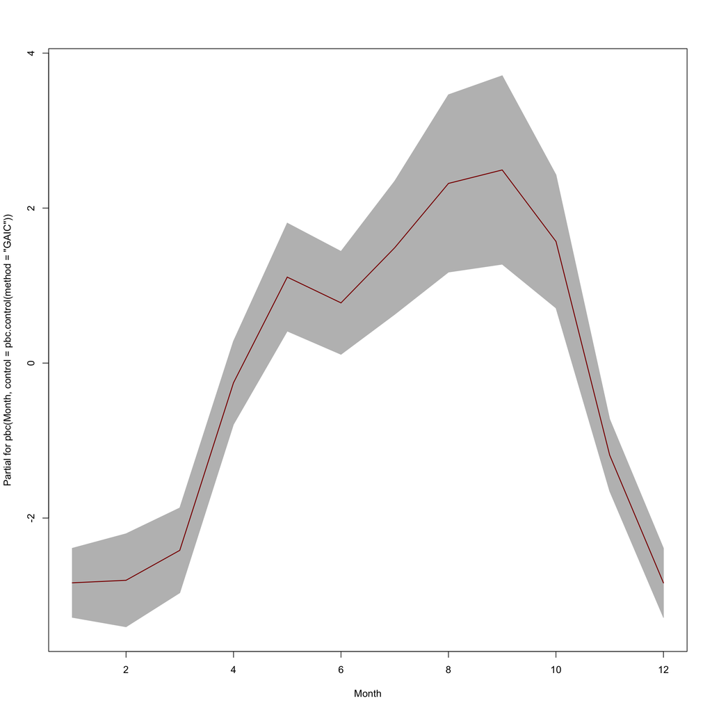

```r
term.plot(m_RWoccwk_bt, parameter = "nu")
```

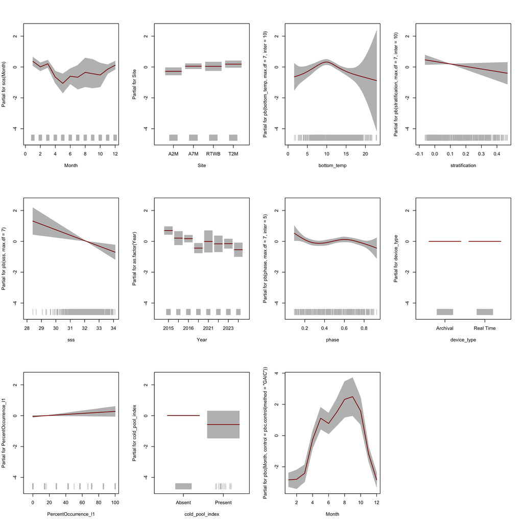

```r
par(mfrow = c(3, 4))
term.plot(m_RWoccwk_bt, rug = TRUE)

term.plot(m_RWoccwk_bt, parameter = "nu")
```

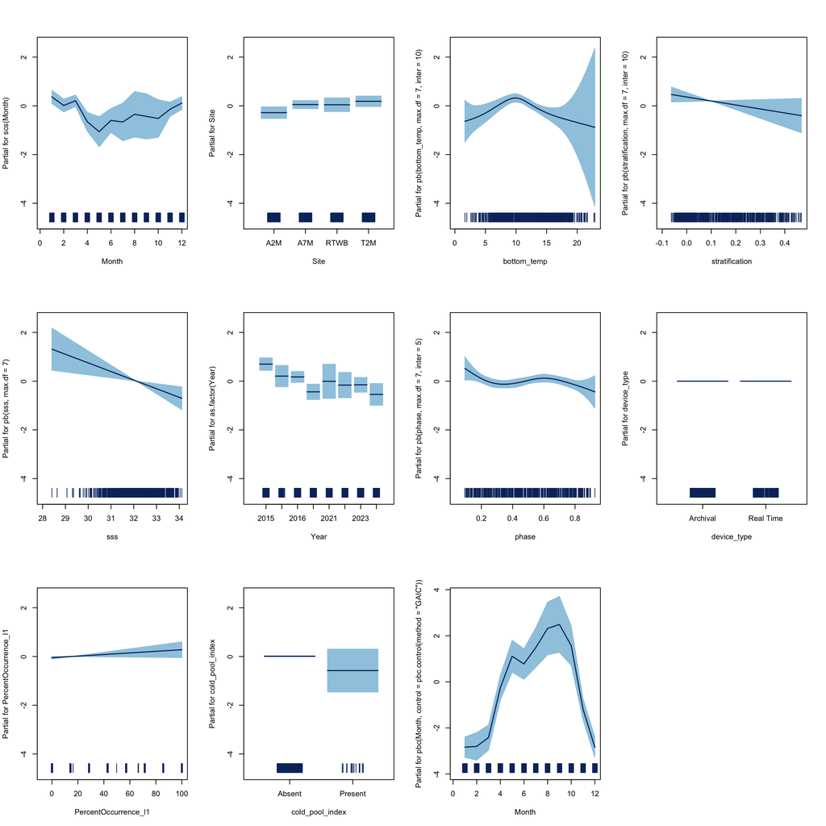

```r
# 1. Set pure white background and multi-panel layout
par(mfrow = c(3, 4), bg = "white")

# 2. Main term plot (location parameter 'mu')
term.plot(
  m_RWoccwk_bt,
  rug = TRUE,
  scheme = "shaded",       # Enables filled confidence intervals
  col.term = "#08306b",     # Dark blue main trend lines/bars
  col.shaded = "#9ecae1",   # Light blue confidence interval fill
  col.se = "#08519c",       # Medium-dark blue SE lines
  col.rug = "#08306a"       # Dark blue rug marks
)

# 3. Term plot for parameter 'nu'
term.plot(
  m_RWoccwk_bt,
  parameter = "nu",
  rug = TRUE,
  scheme = "shaded",
  col.term = "#08306b",
  col.shaded = "#9ecae1",
  col.se = "#08519c",
  col.rug = "#08306a"
)
```

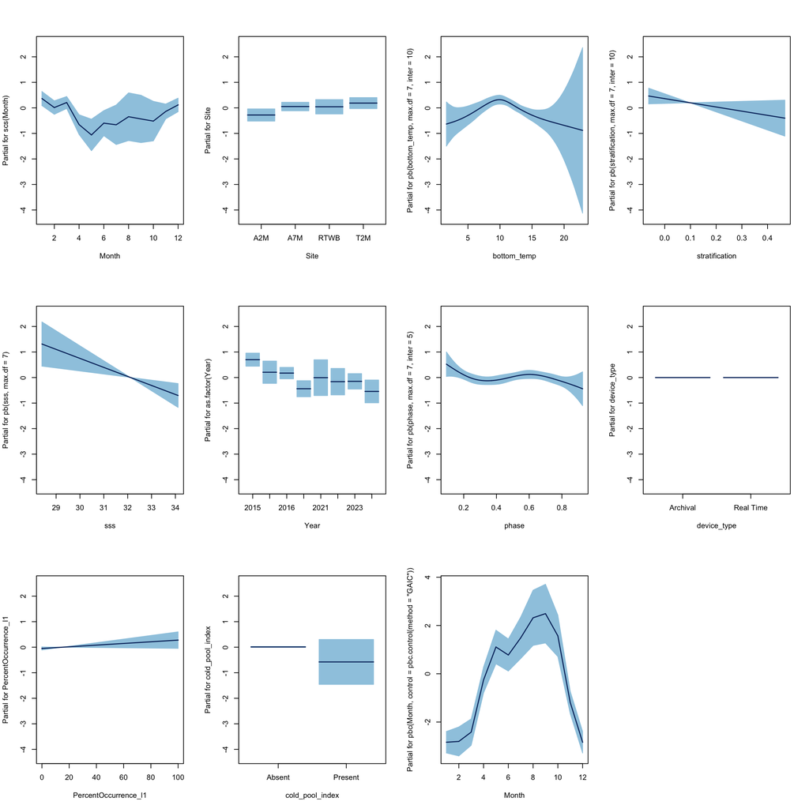

```r
# 1. Set pure white background and multi-panel layout
par(mfrow = c(3, 4), bg = "white")

# 2. Main term plot (location parameter 'mu')
term.plot(
  m_RWoccwk_bt,
  #rug = TRUE,
  scheme = "shaded",       # Enables filled confidence intervals
  col.term = "#08306b",     # Dark blue main trend lines/bars
  col.shaded = "#9ecae1",   # Light blue confidence interval fill
  col.se = "#08519c",       # Medium-dark blue SE lines
  #col.rug = "#08306a"       # Dark blue rug marks
)

# 3. Term plot for parameter 'nu'
term.plot(
  m_RWoccwk_bt,
  parameter = "nu",
  #rug = TRUE,
  scheme = "shaded",
  col.term = "#08306b",
  col.shaded = "#9ecae1",
  col.se = "#08519c",
  #col.rug = "#08306a"
)
```

Test significance of the weekly seasonal `nu` term using a likelihood-ratio test:

```r
drop1(m_RWoccwk_sst, parameter = "nu")
```

```
#> Single term deletions for
#> nu
#>
#> Model:
#> percent_occurrence/100 ~ pbc(Month, control = pbc.control(method = "GAIC"))
#>                                                        Df     AIC    LRT
#> <none>                                                     593.22
#> pbc(Month, control = pbc.control(method = "GAIC")) 7.2726 1019.84 441.17
#>                                                      Pr(Chi)
#> <none>
#> pbc(Month, control = pbc.control(method = "GAIC")) < 2.2e-16 ***
#> ---
#> Signif. codes:  0 '***' 0.001 '**' 0.01 '*' 0.05 '.' 0.1 ' ' 1
```

```r
drop1(m_RWoccwk_strat, parameter = "nu")
```

```
#> Single term deletions for
#> nu
#>
#> Model:
#> percent_occurrence/100 ~ pbc(Month, control = pbc.control(method = "GAIC"))
#>                                                        Df     AIC    LRT
#> <none>                                                     594.09
#> pbc(Month, control = pbc.control(method = "GAIC")) 7.2876 1020.69 441.18
#>                                                      Pr(Chi)
#> <none>
#> pbc(Month, control = pbc.control(method = "GAIC")) < 2.2e-16 ***
#> ---
#> Signif. codes:  0 '***' 0.001 '**' 0.01 '*' 0.05 '.' 0.1 ' ' 1
```

```r
drop1(m_RWoccwk_bt, parameter = "nu")
```

```
#> Single term deletions for
#> nu
#>
#> Model:
#> percent_occurrence/100 ~ pbc(Month, control = pbc.control(method = "GAIC"))
#>                                                        Df    AIC    LRT
#> <none>                                                     592.6
#> pbc(Month, control = pbc.control(method = "GAIC")) 7.2726 1019.2 441.17
#>                                                      Pr(Chi)
#> <none>
#> pbc(Month, control = pbc.control(method = "GAIC")) < 2.2e-16 ***
#> ---
#> Signif. codes:  0 '***' 0.001 '**' 0.01 '*' 0.05 '.' 0.1 ' ' 1
```

```r
# Residual autocorrelation diagnostics by observation stream
weekly_resid <- tibble(
  res = resid(m_RWoccwk_bt),
  Date = weekly_model_data$Date,
  Site = weekly_model_data$Site,
  period = weekly_model_data$period,
  device_type = weekly_model_data$device_type
) %>%
  arrange(Site, period, device_type, Date) %>%
  group_by(Site, period, device_type) %>%
  mutate(res_lag1 = dplyr::lag(res, 1),
         res_lag2 = dplyr::lag(res, 2)) %>%
  ungroup()

# Stream-specific tests identify autocorrelation confined to particular series.
weekly_resid %>%
  group_by(Site, period, device_type) %>%
  filter(sum(!is.na(res)) > 4) %>%
  summarise(n = sum(!is.na(res)),
            lag1_p = Box.test(res[!is.na(res)], lag = 1,
                              type = "Ljung-Box")$p.value,
            lag2_p = Box.test(res[!is.na(res)], lag = 2,
                              type = "Ljung-Box")$p.value,
            .groups = "drop")
```

```
#> # A tibble: 7 × 6
#>   Site  period device_type     n lag1_p lag2_p
#>   <fct> <fct>  <fct>       <int>  <dbl>  <dbl>
#> 1 A2M   1      Archival      150 0.684   0.774
#> 2 A2M   2      Archival       51 0.892   0.752
#> 3 A7M   1      Archival      155 0.247   0.494
#> 4 A7M   2      Archival       51 0.0679  0.138
#> 5 RTWB  2      Real Time     163 0.578   0.478
#> 6 T2M   1      Archival      155 0.319   0.492
#> 7 T2M   2      Archival       51 0.109   0.276
```

```r
# Pooled tests use complete within-stream residual pairs and assess overall
# autocorrelation across the weekly observation streams.
weekly_resid %>%
  summarise(
    lag1_n = sum(complete.cases(res, res_lag1)),
    lag1_p = cor.test(res, res_lag1, use = "complete.obs")$p.value,
    lag2_n = sum(complete.cases(res, res_lag2)),
    lag2_p = cor.test(res, res_lag2, use = "complete.obs")$p.value)
```

```
#> # A tibble: 1 × 4
#>   lag1_n lag1_p lag2_n lag2_p
#>    <int>  <dbl>  <int>  <dbl>
#> 1    769 0.0581    762  0.511
```

Note in the weekly model the lagged percent occurrence term `PercentOccurrence_l1` is included to account for autocorrelation in the response variable. The model diagnostics indicate that this term effectively addresses residual autocorrelation, as evidenced by the lack of significant autocorrelation in the site-specific and pooled tests.